# Day 2 Exercise

# Basic statistics for analysis

In this part, we will practise basic statistical analysis for RNASeq data. Please note, these analysis approaches are general and can be applied to any type of data sets.

In most cases, the input data format is a matrix. In this exercise, we will use a TCGA glioblastoma dataset. The original data source is from https://tcga-data.nci.nih.gov/docs/publications/gbm_exp/.

We will use the following two files:

- TCGA_unified_CORE_ClaNC840.txt: Expression values and subtype calls for the Core TCGA samples using the unified scaled data
- unifiedScaled.txt: unified gene expression estimate for 202 samples and 11,861 genes

In this analysis, researchers predicted four subtypes based on RNASeq data. Here we assume the predicted subtypes are known subtypes.

## Read the data

Before doing any analysis, importing or reading data into R is an important step. Sometimes it is quite straightforward and smooth, but othertimes you might have problems or errors. Knowing how to solve these small but annoying problems will speed up your analysis and give you a good mood for that day.

If it is the first time that you see the data, the first thing is to have a simple look at how the format is. Most datasets are in a format of plain text (or a zipped file that you need to uncomparess it in advance). You can open it in a text editor or Excel (if the size of the file is small) or run following command. `head` prints the first 10 lines in the file.

```
# If you use linux or mac
head TCGA_unified_CORE_ClaNC840.txt
head unifiedScaled.txt
```

We can see the two files are all table-like files. Now we can read it by the `read.table()` function. You might image `read.table()` is a magic function that it automatically converts the file properly into R. If you run following command, you will have an error.

```r
df = read.table("TCGA_unified_CORE_ClaNC840.txt")
```

```
## Error in scan(file = file, what = what, sep = sep, quote = quote, dec = dec, : line 2 did not have 184 elements
```

`read.table()` has some defaults for some parameters. The default separator is a single space while in `TCGA_unified_CORE_ClaNC840.txt`, the second column has some values containing spaces (try command `cut -f2 TCGA_unified_CORE_ClaNC840.txt | sort | uniq` under linux or mac). In this case, we need to explictly set the separator to tab `\t`.

```r
df = read.table("TCGA_unified_CORE_ClaNC840.txt", sep = "\t")
```

```r
head(df)
```

In `df`, the first two rows are what we need, which are sample names and subtypes. The first two columns are not needed here and we need to exclude them.

We can subset `df` to get the first two rows. Note `-(1:2)` means to exclude the first two columns.

```r
sample_id = df[1, -(1:2)]
subtype = df[2, -(1:2)]
```

We need to double check the format of `sample_id` and `subtype`:

```r
sample_id
```

[output not shown]

You might wonder why `sample_id` is in such a strange format. The reason is `df` is a data frame and subsetting the data frame by rows will also give you a data frame, even when the data frame only has one row.

```r
is.data.frame(sample_id)
```

```
## [1] TRUE
```

To convert a one-row data frame to a vector, you need to first convert it to a one-row matrix then to a vector.

```r
sample_id = as.vector(as.matrix(sample_id))
subtype = as.vector(as.matrix(subtype))
# you can check the value of sample_id and subtype
```

Here `subtype` is called **annotation** (of samples) in the analysis. Normally, the annotations are stored as a data frame where rows correspond to samples.

```r
anno = data.frame(subtype = subtype)
rownames(anno) = sample_id
head(anno)
```

```
##                       subtype
## TCGA-02-0003-01A-01 Proneural
## TCGA-02-0010-01A-01 Proneural
## TCGA-02-0011-01B-01 Proneural
## TCGA-02-0014-01A-01 Proneural
## TCGA-02-0024-01B-01 Proneural
## TCGA-02-0026-01B-01 Proneural
```

As you can see, the sample nams are assigned as the row names of the annotation data frame `anno`. Later we can use it to correspond to the expression matrix to make sure the columns in expression matrix and rows in annotation data frame as the same.

For `unifiedScaled.txt`, it is quite clean (which means there are only gene names, sample names and expression matrix in it) and simply use `read.table()` function:

```r
mat = read.table("unifiedScaled.txt")
mat[1:2, 1:2]
```

```
##       TCGA.02.0001.01C.01 TCGA.02.0002.01A.01
## AACS              0.29861             0.14778
## FSTL1            -0.66392            -0.21234
```

`read.table()` always returns a data frame, which means `mat` is actually a data frame. Although in some analysis, it won’t matter whether the input is a matrix or a data frame, but for some other analysis, the input is enforced to be a matrix (e.g. clustering). Thus, we need to convert it to a matrix.

```r
mat = as.matrix(mat)
```

OK, now we successfully read the annotation as well as the main matrix into R and format them properly. To make further analysis, one curcial thing is to check whether the expression matrix and the annotation data frame are corresponded.

```r
intersect(colnames(mat), rownames(anno))
```

```
## character(0)
```

Nothing in common?! If you check the value of `colnames(mat)` and `rownames(ano)`, you will find the format of the sample names are different.

```r
colnames(mat)[1:2]
```

```
## [1] "TCGA.02.0001.01C.01" "TCGA.02.0002.01A.01"
```

```r
rownames(anno)[1:2]
```

```
## [1] "TCGA-02-0003-01A-01" "TCGA-02-0010-01A-01"
```

This is another annoying thing caused by `read.table()`. By default, it will automatically convert a column name like `TCGA-12-0620-01A-01` to `TCGA.12.0620.01A.01` for historical reason. We always need to set `check.names = FALSE` in `read.table()` to avoid such conversion.

```r
mat = read.table("unifiedScaled.txt", check.names = FALSE)
mat = as.matrix(mat)
mat[1:2, 1:2]
```

```
##       TCGA-02-0001-01C-01 TCGA-02-0002-01A-01
## AACS              0.29861             0.14778
## FSTL1            -0.66392            -0.21234
```

```r
intersect(colnames(mat), rownames(anno))
```

```
##   [1] "TCGA-02-0003-01A-01" "TCGA-02-0004-01A-01" "TCGA-02-0006-01B-01" "TCGA-02-0007-01A-01"
##   [5] "TCGA-02-0009-01A-01" "TCGA-02-0010-01A-01" "TCGA-02-0011-01B-01" "TCGA-02-0014-01A-01"
##   [9] "TCGA-02-0016-01A-01" "TCGA-02-0021-01A-01" "TCGA-02-0023-01B-01" "TCGA-02-0024-01B-01"
##  [13] "TCGA-02-0025-01A-01" "TCGA-02-0026-01B-01" "TCGA-02-0027-01A-01" "TCGA-02-0028-01A-01"
##  [17] "TCGA-02-0033-01A-01" "TCGA-02-0034-01A-01" "TCGA-02-0038-01A-01" "TCGA-02-0039-01A-01"
##  [21] "TCGA-02-0043-01A-01" "TCGA-02-0046-01A-01" "TCGA-02-0047-01A-01" "TCGA-02-0048-01A-01"
##  [25] "TCGA-02-0051-01A-01" "TCGA-02-0054-01A-01" "TCGA-02-0055-01A-01" "TCGA-02-0057-01A-01"
##  [29] "TCGA-02-0059-01A-01" "TCGA-02-0060-01A-01" "TCGA-02-0064-01A-01" "TCGA-02-0069-01A-01"
##  [33] "TCGA-02-0070-01A-01" "TCGA-02-0074-01A-01" "TCGA-02-0075-01A-01" "TCGA-02-0079-01A-03"
##  [37] "TCGA-02-0080-01A-01" "TCGA-02-0084-01A-03" "TCGA-02-0085-01A-01" "TCGA-02-0086-01A-01"
##  [41] "TCGA-02-0087-01A-01" "TCGA-02-0089-01A-01" "TCGA-02-0099-01A-01" "TCGA-02-0102-01A-01"
##  [45] "TCGA-02-0104-01A-01" "TCGA-02-0106-01A-01" "TCGA-02-0107-01A-01" "TCGA-02-0111-01A-01"
##  [49] "TCGA-02-0113-01A-01" "TCGA-02-0114-01A-01" "TCGA-02-0115-01A-01" "TCGA-02-0260-01A-03"
##  [53] "TCGA-02-0269-01B-01" "TCGA-02-0281-01A-01" "TCGA-02-0285-01A-01" "TCGA-02-0289-01A-01"
##  [57] "TCGA-02-0290-01A-01" "TCGA-02-0317-01A-01" "TCGA-02-0321-01A-01" "TCGA-02-0325-01A-01"
```

[output cut: 29 more lines]

We check how many samples are there in `mat` and in `anno`:

```r
ncol(mat)
```

```
## [1] 202
```

```r
nrow(anno)
```

```
## [1] 173
```

The numbers are not the same and maybe the order of the samples are also different. We need to take the common samples in the two objects:

```r
cn = intersect(colnames(mat), rownames(anno))
mat = mat[, cn]
anno = anno[cn, , drop = FALSE]
```

Note since `mat` has column names and `anno` has row names, `cn` can be used as character indices for reordering and subsetting objects.

You might note when subsetting `anno`, we additionally add `drop = FALSE` argument. This is another annoying default behavior of R. Since the original `anno` only has one column, doing `anno[cn, ]` will degenerate to a vector (or in other words, the dimension is droppped.)

Now `mat` and `anno` are in nice and correct format and can be used for downstream analysis.

Last but not the least, since we spend so much effort on cleaning the data, we actually can save `anno` and `mat` into files which is also good if you want to re-perform the analysis or share the data with other collaborators.

```r
save(mat, anno, file = ...)  # use load() to read back
saveRDS(mat, file = ...)  # use readRDS() to read back
saveRDS(anno, file = ...)  # use readRDS() to read back
```

## General analysis

Now we know `mat` contains expression data, but what exactly does the expression value look like? Or in other words, how does the distribution of the gene expression look like? The most straightforward way that a lot of people will do is to look at the distribution.

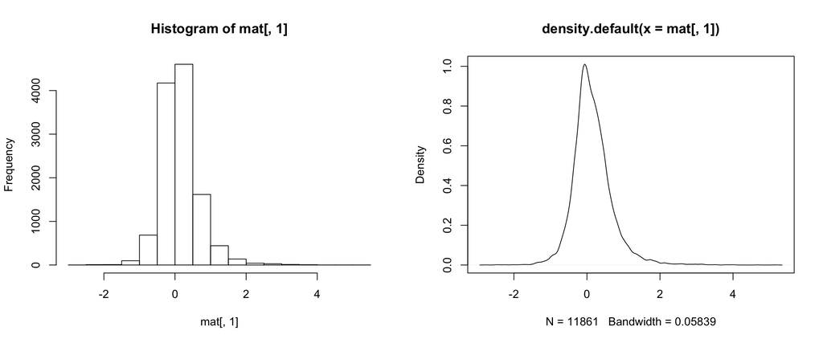

```r
par(mfrow = c(1, 2))  # a layout of one row and two columns
hist(mat[, 1]) # the first column
plot(density(mat[, 1]))
```

```r
par(mfrow = c(1, 1)) # reset the layout, you don't need this line if you just close the graphic window
```

Siimlarlly, you can make density plot for other samples.

According to the density plot, we see the values distributed in both positive and negative values (why the expression values have negative values?). According to the file name of the expression matrix, we can infer the gene expression are “scaled”. Scaling is an approach that converts the data and put data scale of all genes into a similar level.

We can check the mean value and standard deviation of all genes.

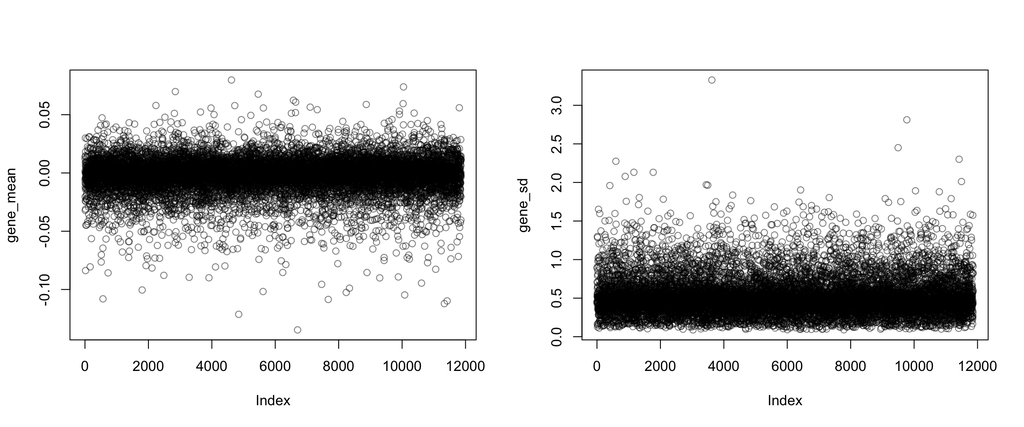

```r
par(mfrow = c(1, 2))
gene_mean = apply(mat, 1, mean) # use ?apply to check what does apply() do
plot(gene_mean, col = "#00000080")
gene_sd = apply(mat, 1, sd)
plot(gene_sd, col = "#00000080")
```

```r
par(mfrow = c(1, 1))
```

We can see the mean expression of all genes are centered at `y = 0` and the sd are close to 0.5. So we can say all the genes are in a similar scale.

To get an impression of how the data distributes, sometimes we don’t need the exact the distribution, while five quantiles are enough for intepration. Recall we can use `boxplot()` function to visualize quantiles.

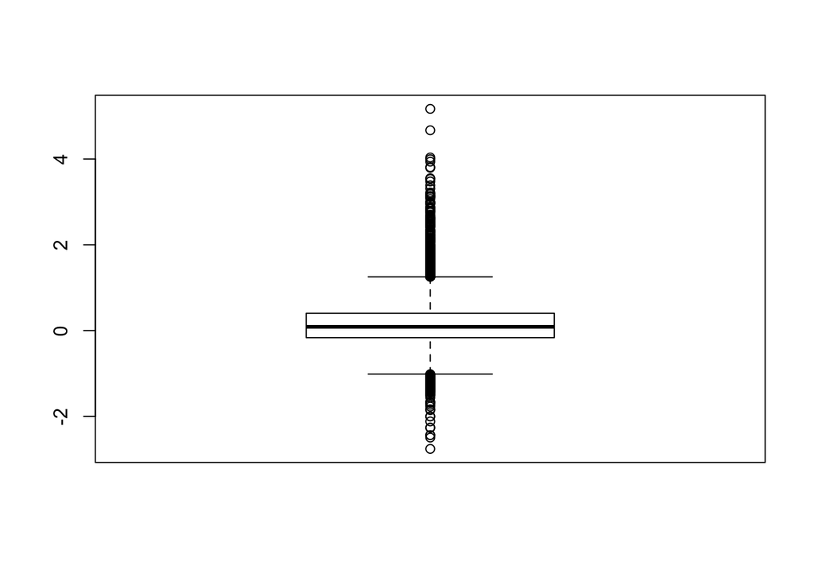

```r
boxplot(mat[, 1])
```

Atually you can put mulitplt boxplots in one plot:

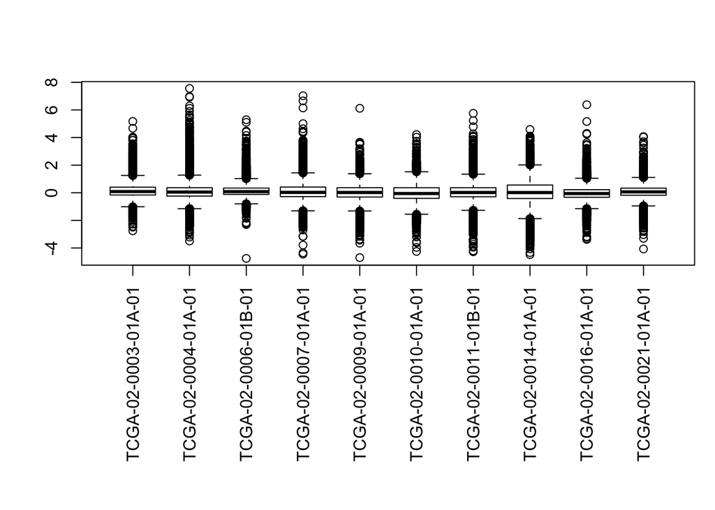

```r
par(las = 3, mar = c(12, 4, 4, 1))  # type ?par to find out what do las and mar mean
boxplot(mat[, 1:10])
```

It seems there are too many outliers that comparess the boxes too small. The outliers can be removed by setting `outline = FALSE`.

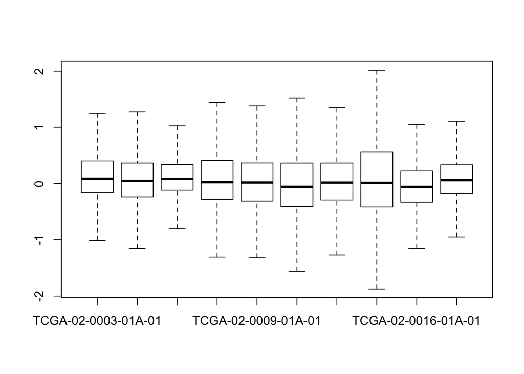

```r
boxplot(mat[, 1:10], outline = FALSE)
```

Recall to get the numbers of the quantiles, use `quantile()` function.

```r
quantile(mat[, 1])
```

```
##       0%      25%      50%      75%     100%
## -2.75794 -0.16462  0.08712  0.40294  5.16804
```

We can calculate correlation between two samples:

```r
cor(mat[, 1], mat[, 2])
```

```
## [1] -0.2545496
```

If you put the matrix into `cor()`, it returns a correlation matrix.

```r
cor_mat = cor(mat)
dim(cor_mat)
```

```
## [1] 173 173
```

Normally we visualize it as a heatmap. If you don’t have **ComplexHeatmap** installed, try following commands:

```r
install.packages("https://cran.r-project.org/src/contrib/circlize_0.4.5.tar.gz", repos = NULL)
install.packages("http://bioconductor.org/packages/devel/bioc/src/contrib/ComplexHeatmap_1.99.3.tar.gz", repos = NULL)
```

Following means we make a heatmap for `cor_mat` and use `anno` as annotation on top and left of the heatmap. Note the colors for annotations are randomly assigned.

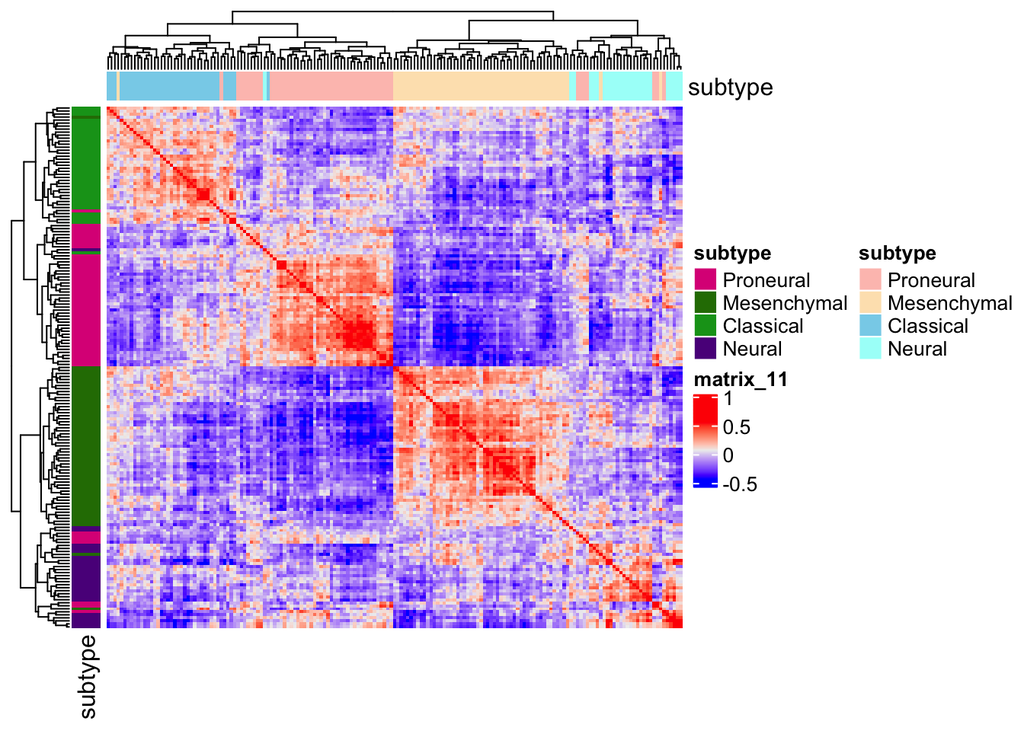

```r
library(ComplexHeatmap)
Heatmap(cor_mat, top_annotation = HeatmapAnnotation(df = anno),
    left_annotation = rowAnnotation(df = anno),
    show_row_names = FALSE, show_column_names = FALSE)
```

Next we will do hypothesis test on samples only in two subtypes (Proneural and Mesenchymal). We first get a subset from `mat` and `anno`.

```r
l = anno$subtype %in% c("Proneural", "Mesenchymal")
mat2 = mat[, l]
anno2 = anno[l, , drop = FALSE]
anno2$subtype = factor(as.character(anno2$subtype), levels = c("Proneural", "Mesenchymal"))
identical(colnames(mat2), rownames(anno2))
```

```
## [1] TRUE
```

Now we want to test how differential the gene “CREB3L1” is in comparison of Proneural vs Mesenchymal. We first get the expression of CREB3L1 and assign the subtype annotation to another variable so that we don’t need to type `anno2$subtyep` too many times in following code.

```r
gene = "CREB3L1"  # ELMO2
x = mat2[gene, ]  # note `gene` is a character and can be used as character index
subtype = anno2$subtype
# you can check the value of `x` and `subtype`
```

Perform two-sample t-test with default settings.

```r
t.test(x ~ subtype)
```

```
##
##  Welch Two Sample t-test
##
## data:  x by subtype
## t = -4.9387, df = 106.97, p-value = 2.916e-06
## alternative hypothesis: true difference in means is not equal to 0
## 95 percent confidence interval:
##  -0.6145674 -0.2625117
## sample estimates:
##   mean in group Proneural mean in group Mesenchymal
##                -0.2768483                 0.1616913
```

`x ~ subtyep` is called a formula in R. It basically means performing test against `subtype` (of course, `subtype` must be a categorical variable). An alternative way to use `t.test()` is to provide two vectors, where each for one subtype.

```r
t.test(x[subtype == "Proneural"], x[subtype == "Mesenchymal"])
```

```
##
##  Welch Two Sample t-test
##
## data:  x[subtype == "Proneural"] and x[subtype == "Mesenchymal"]
## t = -4.9387, df = 106.97, p-value = 2.916e-06
## alternative hypothesis: true difference in means is not equal to 0
## 95 percent confidence interval:
##  -0.6145674 -0.2625117
## sample estimates:
##  mean of x  mean of y
## -0.2768483  0.1616913
```

Use boxplot to visualize how different the two groups are. Here we also use “formula” in `boxplot()`.

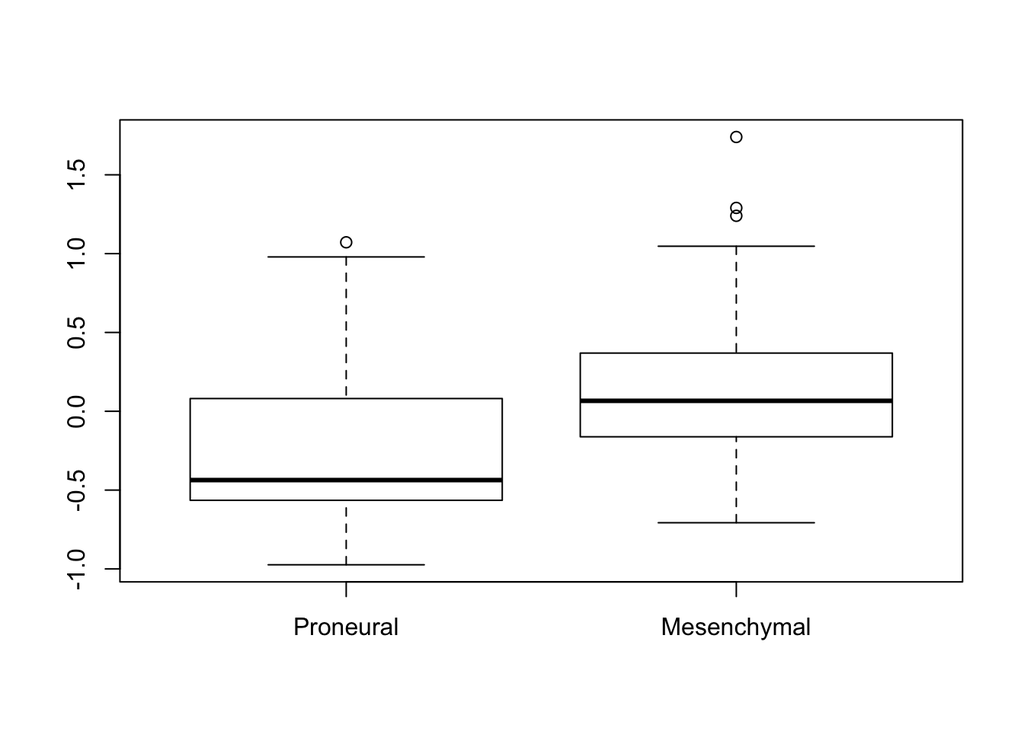

```r
boxplot(x ~ subtype)
```

```r
# same as:
# boxplot(list(Proneural = x[subtype == "Proneural"],
#              Mesenchymal = x[subtype == "Mesenchymal"]))
```

Perform Wilcox rank test is similar as t-test:

```r
wilcox.test(x ~ subtype)
```

```
##
##  Wilcoxon rank sum test with continuity correction
##
## data:  x by subtype
## W = 674, p-value = 9.214e-07
## alternative hypothesis: true location shift is not equal to 0
```

```r
# you can also do:
# wilcox.test(x[subtype == "Proneural"], x[subtype == "Mesenchymal"])
```

Finally, we implement the permutation-based test. Recall we need to design a statistic for the permutation test. In following, the statistic is defined as:

$s = |\frac{\mu_1}{\sigma_1} - \frac{\mu_2}{\sigma_2}|$

We implement the calculation of permutation statistic as a simple function so that it can be used multiple times:

```r
get_score = function(x1, x2) {
    abs(mean(x1)/sd(x1) - mean(x2)/sd(x2))
}
```

The score for the real data (not permutated)

```r
score = get_score(x[subtype == "Proneural"], x[subtype == "Mesenchymal"])
score
```

```
## [1] 0.9514647
```

Next we random permutation `subtype` to produce the null hypothesis that the expression of this gene is not correlated to `subtype`.

```r
n = 1000
score_random = numeric(n)

for(i in 1:n) {
    subtype_random = sample(subtype, length(subtype))
    score_random[i] = get_score(x[subtype_random == "Proneural"], x[subtype_random == "Mesenchymal"])
}
```

`score_random` corresponds that is called “null distribution”. We can see how different between `score` and `score_random` by looking at the position of `score` in `score_random`.

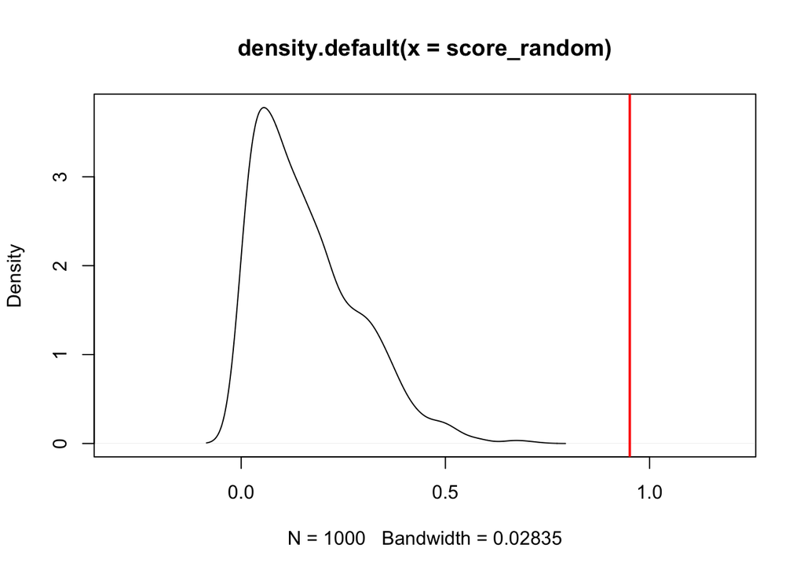

```r
plot(density(score_random), xlim = c(-0.3, 1.2))
abline(v = score, col = "red", lwd = 2)
```

The final p-value is calculated as the probability of `score_random` larger than `score`.

```r
p = sum(score_random > score)/n
p
```

```
## [1] 0
```

Since we only perfrom 1000 permuations, the minimal non-zero p-value is 1/1000 = 0.001, when you see a p-value is zero from a permutaiton test, actually it means the p-value < 0.001 while not really 0.